# Collective Intelligence

Tian Zheng

March 30, 2016

## Collective Intelligence

[From wikipedia] shared or group intelligence that emerges from the collaboration, collective efforts, and competition of many individuals and appears in consensus decision making.

### Web 2.0

[From wikipedia] World Wide Web sites that emphasize user-generated content.

### Examples

- Rankings of products based on reviews
- Suggested friends based on your current friend list
- Ranking of scientific papers based on citations
- Suggested movies based on movies you have watched
- Sorting search results

### Collective flitering

- Our online behaviors are being collected.
- Derive understanding on the latent `qualities` that drive our behaviors.
- Such understanding will guide recommendation engine to give recommendations.
- Including recommendations to ourselves.
- If we like everything the it recommended to us, does that mean it works?

## Project 4: Amazon movie reviews

- http://snap.stanford.edu/data/web-Movies.html
- Number of reviews 7,911,684
- Number of users 889,176
- Number of products 253,059
- Users with > 50 reviews 16,341
- Median no. of words per review 101
- Timespan Aug 1997 - Oct 2012

### Example

> product/productId: B003AI2VGA

> review/userId: A141HP4LYPWMSR

> review/profileName: Brian E. Erland “Rainbow Sphinx”

> review/helpfulness: 7/7

> review/score: 3.0

> review/time: 1182729600

> review/summary: “There Is So Much Darkness Now ~ Come For The Miracle”

> review/text: Synopsis: On the daily trek from …

### Read in the data

- txt raw data was 8.7 GB.
- Very slow for R to process directly.
- Used Python to convert the file to CSV. (see the lib folder)
- For the purpose of this tutorial, I kept
- productId
- userId
- helpfulness
- score
- Output file: output/moiveiscsv.csv

### Parsing the helpfuness votes

```r
movies.raw=read.csv("../output/moviescsv.csv")

movies.raw=movies.raw%>%
  separate(review_helpfulness,
           c("helpful.v", "total.v"), sep = "/",
           remove=FALSE)
movies.raw=movies.raw%>%mutate(review_h=as.numeric(helpful.v)/as.numeric(total.v))

sample_n(movies.raw, 3)
```

```
##         product_productid  review_userid review_helpfulness helpful.v
## 4905642        B004RQDPBE A10QAE2IHI4L6J                2/2         2
## 5084909        B0031P7AW2 A2EV866T978II9                3/3         3
## 6110525        B0012U34QO A2Y3CWITEF9JGY               8/10         8
##         total.v review_score review_h
## 4905642       2            5      1.0
## 5084909       3            5      1.0
## 6110525      10            5      0.8
```

### Compute some user summaries

```r
user.table=movies.raw%>%
                #sample_n(100000)%>%
                group_by(review_userid)%>%
                summarize(
                  user.count=n(),
                  UReview_ave=mean(review_score, na.rm=T),
                  UReview_read=mean(as.numeric(total.v), na.rm=T),
                  UReview_help=mean(review_h, na.rm=T)
                )

head(user.table, n=3)
```

```
## Source: local data frame [3 x 5]
##
##        review_userid user.count UReview_ave UReview_read UReview_help
##               (fctr)      (int)       (dbl)        (dbl)        (dbl)
## 1                            12        4.25     2.833333    0.8785714
## 2 #oc-R1FQ7AEZE601ZD          1        1.00     8.000000    0.3750000
## 3 #oc-R2ZIMCXX9A2H0D          1        1.00    44.000000    0.2727273
```

### Add user summaries to individual reviews

```r
movies.raw=left_join(movies.raw, user.table, by="review_userid")

sample_n(movies.raw, 3)
```

```
##         product_productid  review_userid review_helpfulness helpful.v
## 5297107        B005EJN90K A1VESQ4C53MV67                1/2         1
## 1965049        B000FTCF3G  AWLFWYZNE2QRN                1/1         1
## 806394         B000Q6GUWK  ANBOOQR5NVJPM                8/9         8
##         total.v review_score  review_h user.count UReview_ave UReview_read
## 5297107       2            5 0.5000000          7     5.00000     2.285714
## 1965049       1            1 1.0000000          1     1.00000     1.000000
## 806394        9            5 0.8888889        235     4.93617     6.668085
##         UReview_help
## 5297107    0.5000000
## 1965049    1.0000000
## 806394     0.7473832
```

### Compute some movie summaries

```r
product.table=movies.raw%>%
                #sample_n(100000)%>%
                group_by(product_productid)%>%
                summarize(
                  prod.count=n(),
                  PReview_read=sum(as.numeric(total.v)),
                  PReview_ave=mean(review_score, na.rm=F)
                )

head(product.table, n=3)
```

```
## Source: local data frame [3 x 4]
##
##   product_productid prod.count PReview_read PReview_ave
##              (fctr)      (int)        (dbl)       (dbl)
## 1                           12           34        4.25
## 2        000500005X          3           43        5.00
## 3        000500411X          1            2        5.00
```

```r
movies.raw=left_join(movies.raw, product.table, by="product_productid")
sample_n(movies.raw, 3)
```

```
##         product_productid  review_userid review_helpfulness helpful.v
## 1564894        B004WX8HFG A134C5YR8QEHDG                0/0         0
## 4633828        B008Q00F6K A25WSTU6R12J00                1/1         1
## 57910          B0001NBM44  AE97OLFBE2VSL                3/4         3
##         total.v review_score review_h user.count UReview_ave UReview_read
## 1564894       0            5      NaN         12    5.000000    0.0000000
## 4633828       1            3     1.00         14    3.571429    0.8571429
## 57910         4            2     0.75          1    2.000000    4.0000000
##         UReview_help prod.count PReview_read PReview_ave
## 1564894          NaN        832         4935    3.883413
## 4633828         1.00        228         1551    4.017544
## 57910           0.75          4           13    4.250000
```

### Summary statistics

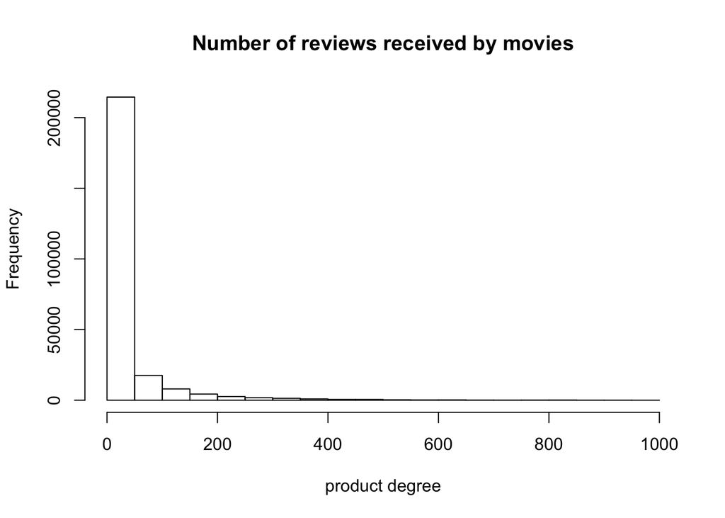

```r
hist(product.table$prod.count, main="Number of reviews received by movies",
     xlab="product degree")
```

```r
product.table$product_productid[which.max(product.table$prod.count)]
```

```
## [1] B002QZ1RS6
## 253060 Levels:  000500005X 000500411X 000504846X 000510372X ... B009W02BXS
```

```r
library(rvest)
ASIN.inq="B001TK80AW"
movie1<- html(paste("http://www.amazon.com/exec/obidos/ASIN/",
                    ASIN.inq, sep=""))
movie1 %>%
  html_node("title") %>%
  html_text()
```

```
## [1] "Amazon.com: V for Vendetta: Roger Allam, Amelda Brown, Charles Cork, Sinad Cusack, Stephen Fry, Rupert Graves, John Hurt, Ben Miles, Tim Pigott-Smith, Andy Rashleigh, Stephen Rea, John Standing, Hugo Weaving, John Ringham, Richard Campbell, Guy Henry, Dulcie Smart, Natalie Portman, Gregory D…
```

Compare mean and median

```r
median(product.table$prod.count)
```

```
## [1] 6
```

```r
mean(product.table$prod.count)
```

```
## [1] 31.26411
```

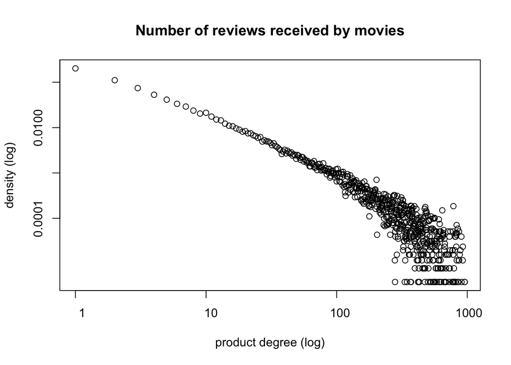

```r
log.hist=hist(product.table$prod.count,
              breaks=(0):max(product.table$prod.count)+0.5,
              plot=F)
plot(log(log.hist$breaks[-1]-0.5)/log(10), log(log.hist$density)/log(10),
     #type="h",
     main="Number of reviews received by movies",
     xaxt="n", yaxt="n",
     xlab="product degree (log)",
     ylab="density (log)")
axis(1, at=0:4, labels=format(10^(0:4), scientific = F))
axis(2, at=-(4:0), labels=format(10^(-(4:0)), scientific = F))
```

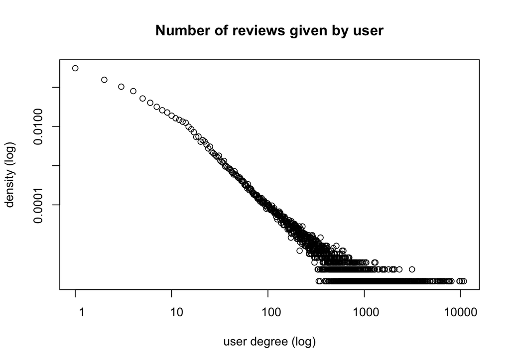

```r
log.hist=hist(user.table$user.count,
              breaks=(0):max(user.table$user.count)+0.5,
              plot=F)
plot(log(log.hist$breaks[-1]-0.5)/log(10), log(log.hist$density)/log(10),
     #type="h",
     main="Number of reviews given by user",
     xaxt="n", yaxt="n",
     xlab="user degree (log)",
     ylab="density (log)")
axis(1, at=0:4, labels=format(10^(0:4), scientific = F))
axis(2, at=-(4:0), labels=format(10^(-(4:0)), scientific = F))
```

#### Power-law distribution

- The shape of the histogram of the number of reviews received by movies on the log-scale suggest a possible [scale-free](https://en.wikipedia.org/wiki/Scale-free_network) network.
- Possible explanations for scale-free networks include preferential attachment and fitness models.

### Which are the best movies?

First let’s look at simple average of reviews

```r
movies.summary=movies.raw%>%
                  #sample_n(10000)%>%
                  group_by(product_productid)%>%
                  summarize(
                    reviewCt=n(),
                    reviewAvg=mean(review_score, na.rm=T))

best.movie=movies.summary$product_productid[which.max(movies.summary$reviewAvg)]
best.movie=as.character(best.movie)
movies.summary[which.max(movies.summary$reviewAvg),]
```

```
## Source: local data frame [1 x 3]
##
##   product_productid reviewCt reviewAvg
##              (fctr)    (int)     (dbl)
## 1        000500005X        3         5
```

```r
library(rvest)

ASIN.inq=best.movie
movie.url=paste("http://www.amazon.com/exec/obidos/ASIN/",
                    ASIN.inq, sep="")
movie1<- html(movie.url)
browseURL(movie.url, browser = getOption("browser"),
          encodeIfNeeded = FALSE)


movie1.title=movie1 %>%
              html_node("title") %>%
              html_text()
```

By simple recommendation, we have [Amazon.com: Pope John Paul II: The Movie [VHS]: Albert Finney, Michael Crompton, Herbert Wise: Movies & TV](http://www.amazon.com/exec/obidos/ASIN/000500005X) as the best movie.

#### Other simple modifications

We can use a Bayesian approach to adjust for movies with few reviews.

```r
movies.summary=movies.raw%>%
                  #sample_n(10000)%>%
                  group_by(product_productid)%>%
                  summarize(
                    reviewCt=n(),
                    reviewAvg=mean(review_score, na.rm=T))%>%
                  mutate(reviewBAvg=(reviewAvg*reviewCt+3*6)/(reviewCt+6))

best.movie=movies.summary$product_productid[which.max(movies.summary$reviewBAvg)]
best.movie=as.character(best.movie)
movies.summary[which.max(movies.summary$reviewBAvg),]
```

```
## Source: local data frame [1 x 4]
##
##   product_productid reviewCt reviewAvg reviewBAvg
##              (fctr)    (int)     (dbl)      (dbl)
## 1        B007MDB6RO      553  4.965642   4.944544
```

```r
library(rvest)

ASIN.inq=best.movie
movie.url=paste("http://www.amazon.com/exec/obidos/ASIN/",
                    ASIN.inq, sep="")
movie1<- html(movie.url)
browseURL(movie.url, browser = getOption("browser"),
          encodeIfNeeded = FALSE)


movie1.title=movie1 %>%
              html_node("title") %>%
              html_text()
```

By Bayesian method recommendation, we have [Amazon.com: GCB: Season 1: Kristin Chenoweth, Annie Potts, Leslie Bibb, Jennifer Aspen: Movies & TV](http://www.amazon.com/exec/obidos/ASIN/B007MDB6RO) as the best movie.

#### normalized rating

Another method would be to normalize individual users’ review by their overall review levels.

### Information other than reviews

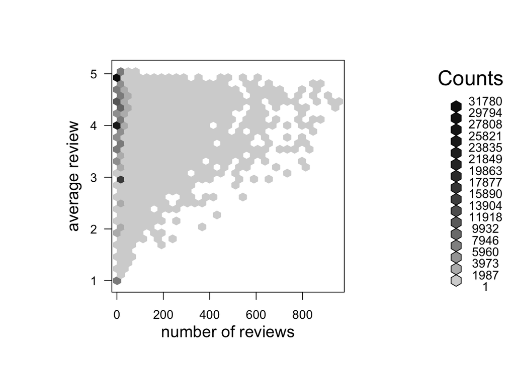

```r
plot(hexbin(product.table$prod.count, product.table$PReview_ave),
     xlab="number of reviews",
     ylab="average review")
```

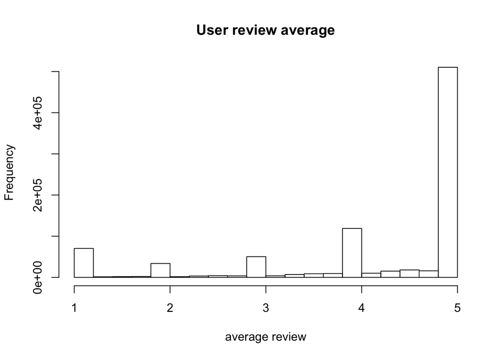

```r
hist(user.table$UReview_ave,
     main="User review average",
     xlab="average review")
```

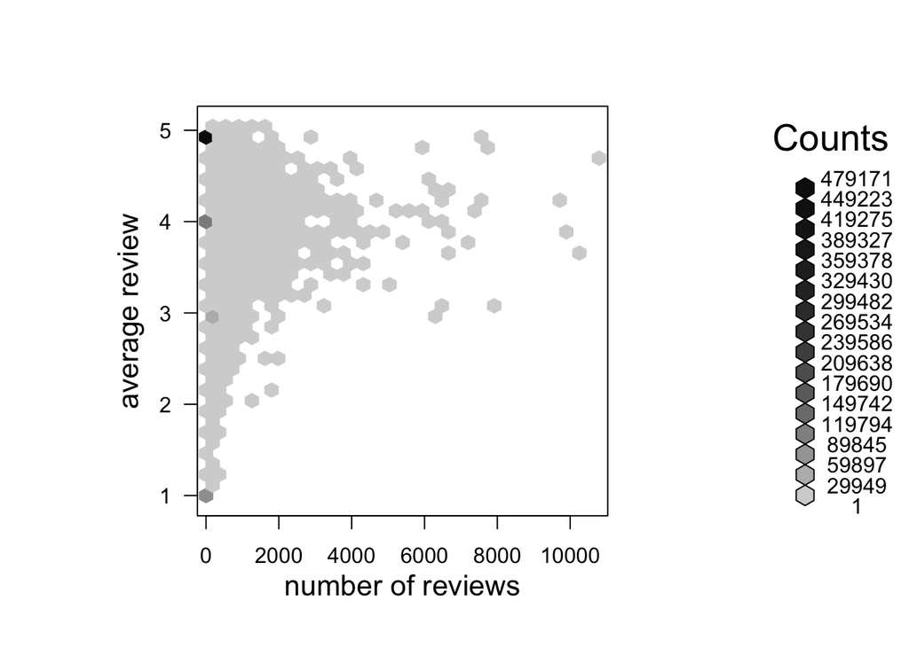

```r
plot(hexbin(user.table$user.count, user.table$UReview_ave),
     xlab="number of reviews",
     ylab="average review")
```

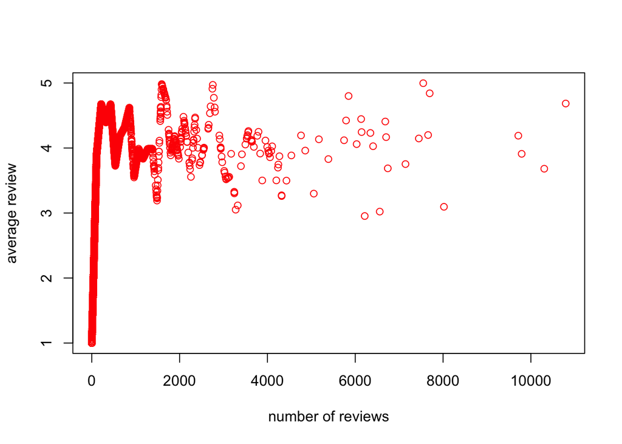

```r
plot(lowess(user.table$user.count, user.table$UReview_ave), col=2,
     xlab="number of reviews",
     ylab="average review")
```

### Collective filtering

- For each movie, we have a set of reviews.
- We can compare a pair of movies using these reviews and the users who wrote these reviews.
- For each user, we have a set of movies a user reviewed.
- We can compare a pair of users using the movies they like.
- A collective filter will be built upon similarity between movies and similarity between users.
- For a new user with a few reviews, we can
- identify similar users and recommend movies liked by these users.
- or recommend movies similar to the movies already liked by this user.
- a combined recommendation (weighted ranking).